# SD-DRM Analysis

Sumit Jyoti

2026-08-22

# 1 Exposure data and model parameters

The exposure file contains 1,000 variability draws, each representing the dose for a simulated shrimp-consumption day. The same dose vector is evaluated under 500 paired pharmacodynamic uncertainty draws. In the resulting risk matrix, rows represent shrimp-consumption days and columns represent uncertainty draws.

```r
exposure <- read.csv("raw_shrimp_mc2d_simulation_data.csv") |>
  arrange(inner_id)

n_inner <- nrow(exposure)
n_outer <- 500

dose_inner <- exposure$D_raw
dose <- rep(dose_inner, times = n_outer)
dose_percentiles <- quantile(dose_inner, c(0.025, 0.50, 0.975), names = FALSE)
median_dose <- dose_percentiles[2]
median_log10_dose <- log10(median_dose)

alpha <- 0.60
beta <- 1.31e6
tfs <- 1
MIC <- 0.13

fr_fixed <- 0.20
pMIC_fixed <- 2

pMIC_seq <- seq(0, 10, by = 0.1)
pMIC_plot <- c(0, 2, 5)
pMIC_breaks <- 0:10

fr_seq <- seq(0, 0.5, by = 0.025)
fr_plot <- c(0, 0.2, 0.5)
fr_breaks <- seq(0, 0.5, by = 0.05)


pMIC_colours <- c("0% MIC" = "#F8766D", "2% MIC" = "#00BFC4", "5% MIC" = "#C77CFF")
fr_colours <- c("fr = 0" = "#F8766D", "fr = 0.2" = "#7CAE00", "fr = 0.5" = "#C77CFF")
```

# 2 Pharmacodynamic uncertainty

The Emax and EC50 estimates are sampled together from their fitted bivariate normal distribution, expressed in the units used by the SD-DRM. Sampling them as pairs preserves their estimated relationship.

```r
pd_estimates <- c(Emax_per_day = 81.587790, EC50_ug_mL = 0.166877)

pd_covariance <- matrix(c(32.631766, 0.124149033, 0.124149033, 0.002101326), nrow = 2, byrow = TRUE)

draw_pd <- function(n) {
  x <- MASS::mvrnorm(n, pd_estimates, pd_covariance)
  invalid <- x[, 1] <= 0 | x[, 2] <= 0

  while (any(invalid)) {
    x[invalid, ] <- MASS::mvrnorm(sum(invalid), pd_estimates, pd_covariance)
    invalid <- x[, 1] <= 0 | x[, 2] <= 0
  }

  data.frame(Emax_per_day = x[, 1], EC50_ug_mL = x[, 2])
}

set.seed(seed)
pd <- draw_pd(n_outer)
Emax_outer <- pd$Emax_per_day
EC50_outer <- pd$EC50_ug_mL

# Descriptive summary
summarise_pd <- function(x) {
  q <- quantile(x, c(0.025, 0.25, 0.50, 0.75, 0.975), na.rm = TRUE, names = FALSE)
  data.frame(Mean = mean(x, na.rm = TRUE), P2.5 = q[1], P25 = q[2], Median = q[3],
             P75 = q[4], P97.5 = q[5], Minimum = min(x, na.rm = TRUE),
             Maximum = max(x, na.rm = TRUE))
}

pd_labels <- c(Emax_per_day = "Emax (day^-1)",
               EC50_ug_mL = "EC50 (µg/mL)")

pd_summary <- do.call(rbind, lapply(names(pd_labels), function(x) {
  data.frame(Parameter = unname(pd_labels[x]), summarise_pd(pd[[x]]))
}))

rownames(pd_summary) <- NULL
print(pd_summary)
```

```
##       Parameter       Mean        P2.5        P25     Median        P75
## 1 Emax (day^-1) 81.3901944 70.16322683 77.6736140 81.4696396 84.8704097
## 2  EC50 (µg/mL)  0.1662194  0.07300716  0.1376031  0.1652588  0.1982813
##        P97.5     Minimum    Maximum
## 1 91.7230173 63.07359757 96.7878551
## 2  0.2580285  0.02426117  0.2901687
```

```r
dir.create("results", showWarnings = FALSE)
write.csv(pd_summary, file.path("results", "pd_uncertainty_summary.csv"), row.names = FALSE)
```

# 3 SD-DRM simulation

The original beta-Poisson alpha and beta describe the response without an antibiotic effect. They can therefore be used directly for the resistant subpopulation, but not for susceptible bacteria exposed to doxycycline. `make_ab_lookup()` generates r values from the original beta-Poisson model, adjusts them using the doxycycline concentration and paired Emax-EC50 draws, and obtains the adjusted alpha and beta for the susceptible subpopulation. `calc_sd_drm()` then splits the dose into susceptible and resistant components and combines their extinction probabilities to calculate the total illness risk.

```r
ab_lookup <- make_ab_lookup(
  alpha = alpha,
  beta = beta,
  Emax = Emax_outer,
  EC50 = EC50_outer,
  C_max = max(pMIC_seq) / 100 * MIC,
  tfs = tfs,
  n_grid = 250,
  seed = 0,
  nsim = 1000
)

run_scenario <- function(fr, pMIC) {
  out <- calc_sd_drm(
    dose = dose,
    fr = fr,
    C = pMIC / 100 * MIC,
    alpha = alpha,
    beta = beta,
    Emax = rep(Emax_outer, each = n_inner),
    EC50 = rep(EC50_outer, each = n_inner),
    tfs = tfs,
    ab_lookup = ab_lookup
  )

  list(
    risk = matrix(out$risk_total, nrow = n_inner, ncol = n_outer),
    delta = matrix(out$delta_p_treat, nrow = n_inner, ncol = n_outer)
  )
}

summarise_risk <- function(vary_by, values,
                           fixed_fr = NULL, fixed_pMIC = NULL) {
  map_dfr(values, function(value) {
    fr <- if (vary_by == "fr") value else fixed_fr
    pMIC <- if (vary_by == "pMIC") value else fixed_pMIC
    x <- run_scenario(fr, pMIC)

    expected_risk <- colMeans(x$risk)
    log10_expected_risk <- log10(
      pmax(expected_risk, .Machine$double.xmin)
    )

    q_original <- quantile(
      expected_risk,
      c(0.025, 0.50, 0.975),
      names = FALSE
    )

    q_log10 <- quantile(
      log10_expected_risk,
      c(0.025, 0.25, 0.50, 0.75, 0.975),
      names = FALSE
    )

    prop_more <- mean(x$delta > 0)

    data.frame(
      value = value,

      # Original-scale values retained for plotting
      lower95_expected_risk = q_original[1],
      median_expected_risk = q_original[2],
      upper95_expected_risk = q_original[3],

      # Log10 values retained for the CSV summary
      Mean_log10_expected_risk = mean(log10_expected_risk),
      P2.5_log10_expected_risk = q_log10[1],
      P25_log10_expected_risk = q_log10[2],
      Median_log10_expected_risk = q_log10[3],
      P75_log10_expected_risk = q_log10[4],
      P97.5_log10_expected_risk = q_log10[5],
      Minimum_log10_expected_risk = min(log10_expected_risk),
      Maximum_log10_expected_risk = max(log10_expected_risk),

      prop_more_likely_treatable = prop_more,
      outcome = ifelse(
        prop_more > 0.5,
        "More likely treatable",
        "Less likely treatable"
      )
    )
  })
}

find_cutoff <- function(data, vary_by, fixed_fr = NULL, fixed_pMIC = NULL,
                        tolerance = 0.0001) {
  data <- arrange(data, value)
  above <- data$prop_more_likely_treatable > 0.5
  i <- which(head(above, -1) & !tail(above, -1))[1]
  if (is.na(i)) return(NA_real_)

  uniroot(
    function(value) {
      summarise_risk(vary_by, value, fixed_fr, fixed_pMIC)$prop_more_likely_treatable - 0.5
    },
    interval = data$value[c(i, i + 1)],
    tol = tolerance
  )$root
}
```

# 4 Dose-response curves

These curves use a fixed dose grid, so they show dose-response uncertainty from the paired Emax-EC50 draws without exposure variability. Dose and illness probability are transformed to log10 for plotting.

```r
dose_grid <- 10^seq(log10(min(dose)), log10(max(dose)), length.out = 300)

point_id <- unique(round(seq(1, length(dose_grid), length.out = 10)))

run_dose_grid <- function(fr, pMIC) {
  out <- calc_sd_drm(
    dose = rep(dose_grid, each = n_outer),
    fr = fr,
    C = pMIC / 100 * MIC,
    alpha = alpha,
    beta = beta,
    Emax = rep(Emax_outer, times = length(dose_grid)),
    EC50 = rep(EC50_outer, times = length(dose_grid)),
    tfs = tfs,
    ab_lookup = ab_lookup
  )

  list(
    risk = matrix(out$risk_total, nrow = n_outer),
    delta = matrix(out$delta_p_treat, nrow = n_outer),
    status = matrix(out$status, nrow = n_outer)
  )
}

make_dose_response <- function(vary_by, values, panel_values) {
  expand_grid(panel_value = panel_values, value = values) |>
    pmap_dfr(function(panel_value, value) {
    if (vary_by == "pMIC") {
  pMIC <- value
  fr <- panel_value
  panel <- paste0("Resistant fraction (fᵣ) = ", panel_value)
  group <- paste0(value, "% MIC")
} else {
  fr <- value
  pMIC <- panel_value
  panel <- paste0("pMIC = ", panel_value, "% MIC")
  group <- paste0("fr = ", value)
}

      out <- run_dose_grid(fr, pMIC)
      q <- apply(out$risk, 2, quantile, probs = c(0.025, 0.50, 0.975), names = FALSE)

      data.frame(
        dose = dose_grid,
        lower95 = q[1, ],
        median_risk = q[2, ],
        upper95 = q[3, ],
        group = group,
        panel = panel,
        status = apply(out$status, 2, function(x) names(which.max(table(x)))),
        show_point = seq_along(dose_grid) %in% point_id
      )
    })
}

make_pairwise_data <- function(data, comparisons) {
  imap_dfr(comparisons, function(groups, comparison_name) {
    filter(data, group %in% groups) |>
      mutate(comparison = comparison_name)
  })
}

save_plot <- function(plot, file, width, height) {
  dir.create("images", showWarnings = FALSE)
  print(plot)
  ggsave(file.path("images", file), plot, width = width, height = height, dpi = 600, bg = "white")
}

plot_dose_response_2d <- function(
    data, title, group_title, colours, file_name
) {
  stopifnot(all(data$dose > 0, data$lower95 > 0,
                data$median_risk > 0, data$upper95 > 0))

  data <- mutate(
    data,
    log10_dose = log10(dose),
    log10_lower95 = log10(lower95),
    log10_median_risk = log10(median_risk),
    log10_upper95 = log10(upper95)
  )

  dose_reference_lines <- data.frame(
    log10_dose = log10(dose_percentiles),
    reference = factor(
      c("95% dose variability", "Median dose", "95% dose variability"),
      levels = c("Median dose", "95% dose variability")
    )
  )

  combined_legend_levels <- c(
    "Treatment outcome:", "Less likely treatable", "More likely treatable",
    "Exposure dose:", "Median dose", "95% dose variability"
  )

  p <- ggplot(data, aes(log10_dose, colour = group, fill = group)) +
    geom_ribbon(
      aes(ymin = log10_lower95, ymax = log10_upper95),
      alpha = 0.45, colour = NA, show.legend = FALSE
    ) +
    geom_vline(
      data = dose_reference_lines,
      aes(xintercept = log10_dose, linetype = reference),
      inherit.aes = FALSE, colour = "grey30", linewidth = 0.40
    ) +
    geom_line(aes(y = log10_median_risk), linewidth = 1.05) +
    geom_point(
      data = filter(data, show_point),
      aes(y = log10_median_risk, shape = status),
      size = 3.5
    ) +
    facet_grid(comparison ~ panel) +
    scale_x_continuous(breaks = scales::breaks_pretty(n = 6)) +
    scale_y_continuous(breaks = scales::breaks_pretty(n = 6)) +
    scale_colour_manual(
      name = group_title,
      values = colours,
      breaks = names(colours)
    ) +
    scale_fill_manual(
      name = group_title,
      values = colours,
      breaks = names(colours)
    ) +
    scale_shape_manual(
      name = NULL,
      limits = combined_legend_levels,
      breaks = combined_legend_levels,
      values = c(
        "Treatment outcome:" = NA,
        "Less likely treatable" = 17,
        "More likely treatable" = 16,
        "Exposure dose:" = NA,
        "Median dose" = NA,
        "95% dose variability" = NA
      ),
      drop = FALSE
    ) +
    scale_linetype_manual(
      name = NULL,
      limits = combined_legend_levels,
      breaks = combined_legend_levels,
      values = c(
        "Treatment outcome:" = "blank",
        "Less likely treatable" = "blank",
        "More likely treatable" = "blank",
        "Exposure dose:" = "blank",
        "Median dose" = "solid",
        "95% dose variability" = "dashed"
      ),
      drop = FALSE
    ) +
    labs(
      title = title,
      x = expression(log[10] * "(pathogenic dose [MPN per shrimp-consumption day])"),
      y = expression(log[10] * "(" * P[illness] * ")"),
      caption = expression(
        "Shaded areas show 95% uncertainty intervals from paired " *
          E[max] * "-" * EC[50] * " draws."
      )
    ) +
    guides(
      fill = "none",
      colour = guide_legend(order = 1, nrow = 1),
      shape = guide_legend(
        order = 2, nrow = 1,
        theme = theme(legend.text = element_text(size = 12)),
        override.aes = list(size = 3)
      ),
      linetype = guide_legend(
        order = 2, nrow = 1,
        theme = theme(legend.text = element_text(size = 12)),
        override.aes = list(linewidth = 0.7)
      )
    ) +
    theme_bw(base_size = 11) +
    theme(
      plot.title = element_text(face = "bold"),
      axis.title.x = element_text(size = 14),
      axis.title.y = element_text(size = 14),
      strip.text = element_text(face = "bold", size = 13),
      plot.caption = element_text(size = 11, hjust = 1),
      panel.grid.minor = element_blank(),
      legend.position = "top",
      legend.box = "vertical",
      legend.box.just = "center",
      legend.spacing.y = grid::unit(0.05, "cm")
    )

  save_plot(p, file_name, width = 12, height = 9)
}
```

## 4.1 Residual doxycycline concentration

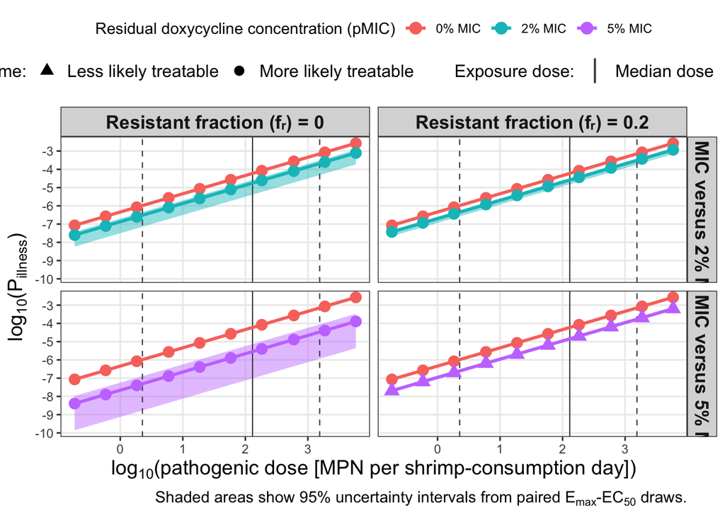

```r
dose_response_pMIC <- make_dose_response("pMIC", pMIC_plot, panel_values = c(0, fr_fixed))

pMIC_comparisons <- make_pairwise_data(
  dose_response_pMIC,
  list(
    "0% MIC versus 2% MIC" = c("0% MIC", "2% MIC"),
    "0% MIC versus 5% MIC" = c("0% MIC", "5% MIC")
  )
)

plot_dose_response_2d(
  pMIC_comparisons,
  title = NULL,
  group_title = "Residual doxycycline concentration (pMIC)",
  colours = pMIC_colours,
  file_name = "dose_response_varying_pMIC.png"
)
```

## 4.2 Resistant fraction

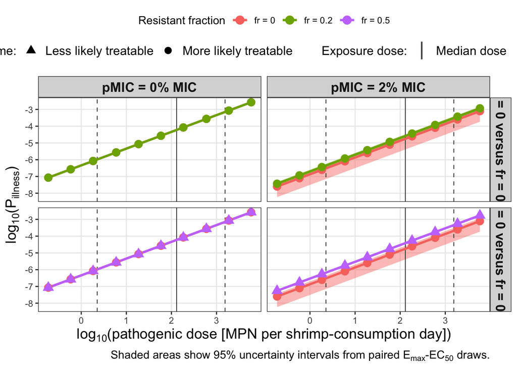

```r
dose_response_fr <- make_dose_response("fr", fr_plot, panel_values = c(0, pMIC_fixed))

fr_comparisons <- make_pairwise_data(
  dose_response_fr,
  list(
    "fr = 0 versus fr = 0.2" = c("fr = 0", "fr = 0.2"),
    "fr = 0 versus fr = 0.5" = c("fr = 0", "fr = 0.5")
  )
)

plot_dose_response_2d(
  fr_comparisons,
  title = NULL,
  group_title = "Resistant fraction",
  colours = fr_colours,
  file_name = "dose_response_varying_fr.png"
)
```

# 5 Dose-response summary at the median exposure dose

For each scenario shown in the two dose-response figures, illness risk is summarized at the median exposure dose across the paired Emax-EC50 uncertainty draws. The dose and illness-risk summaries are reported on the log10 scale.

```r
summarise_risk_at_dose <- function(fr, pMIC) {
  out <- calc_sd_drm(
    dose = rep(median_dose, n_outer), fr = fr, C = pMIC / 100 * MIC,
    alpha = alpha, beta = beta, Emax = Emax_outer, EC50 = EC50_outer,
    tfs = tfs, ab_lookup = ab_lookup
  )

  x <- log10(pmax(out$risk_total, .Machine$double.xmin))
  q <- quantile(x, c(0.025, 0.25, 0.50, 0.75, 0.975), names = FALSE)
  outcome <- ifelse(mean(out$delta_p_treat > 0) > 0.5,
                    "More likely treatable", "Less likely treatable")

  data.frame(
    fr = fr, pMIC = pMIC, Median_log10_dose = median_log10_dose,
    Treatment_outcome_at_median_dose = outcome,
    Mean_log10_risk = mean(x), P2.5_log10_risk = q[1],
    P25_log10_risk = q[2], Median_log10_risk = q[3],
    P75_log10_risk = q[4], P97.5_log10_risk = q[5],
    Minimum_log10_risk = min(x), Maximum_log10_risk = max(x)
  )
}

dose_response_summary_pMIC <- expand_grid(fr = c(0, fr_fixed), pMIC = pMIC_plot) |>
  pmap_dfr(function(fr, pMIC) summarise_risk_at_dose(fr, pMIC)) |>
  mutate(Panel = paste0("Resistant fraction = ", fr),
         Scenario = paste0(pMIC, "% MIC")) |>
  select(Panel, Scenario, everything())

dose_response_summary_fr <- expand_grid(pMIC = c(0, pMIC_fixed), fr = fr_plot) |>
  pmap_dfr(function(pMIC, fr) summarise_risk_at_dose(fr, pMIC)) |>
  mutate(Panel = paste0("pMIC = ", pMIC, "% MIC"),
         Scenario = paste0("fr = ", fr)) |>
  select(Panel, Scenario, everything())

dose_response_summary_table <- bind_rows(
  "Varying residual doxycycline concentration" = dose_response_summary_pMIC,
  "Varying resistant fraction" = dose_response_summary_fr,
  .id = "Figure"
)

print(dose_response_summary_table)
```

```
##                                        Figure                    Panel Scenario
## 1  Varying residual doxycycline concentration   Resistant fraction = 0   0% MIC
## 2  Varying residual doxycycline concentration   Resistant fraction = 0   2% MIC
## 3  Varying residual doxycycline concentration   Resistant fraction = 0   5% MIC
## 4  Varying residual doxycycline concentration Resistant fraction = 0.2   0% MIC
## 5  Varying residual doxycycline concentration Resistant fraction = 0.2   2% MIC
## 6  Varying residual doxycycline concentration Resistant fraction = 0.2   5% MIC
## 7                  Varying resistant fraction            pMIC = 0% MIC   fr = 0
## 8                  Varying resistant fraction            pMIC = 0% MIC fr = 0.2
## 9                  Varying resistant fraction            pMIC = 0% MIC fr = 0.5
## 10                 Varying resistant fraction            pMIC = 2% MIC   fr = 0
## 11                 Varying resistant fraction            pMIC = 2% MIC fr = 0.2
## 12                 Varying resistant fraction            pMIC = 2% MIC fr = 0.5
##     fr pMIC Median_log10_dose Treatment_outcome_at_median_dose Mean_log10_risk
## 1  0.0    0          2.114687            More likely treatable       -4.224468
```

[output cut: 37 more lines]

```r
dir.create("results", showWarnings = FALSE)
write.csv(dose_response_summary_table,
          file.path("results", "dose_response_at_median_dose_summary.csv"),
          row.names = FALSE)
```

# 6 Illness risk

For each uncertainty draw, the mean across shrimp-consumption days gives the illness risk. The median and 95% interval across the outer draws then describe uncertainty in that expected risk. Treatment outcome is assigned to each simulation from the sign of Delta P_treat, and the scenario is classified by the majority of those outcomes. The treatment cut-point is where the proportion classified as more likely treatable falls to 0.5. Expected-risk values are transformed to log10 for plotting and tabular export.

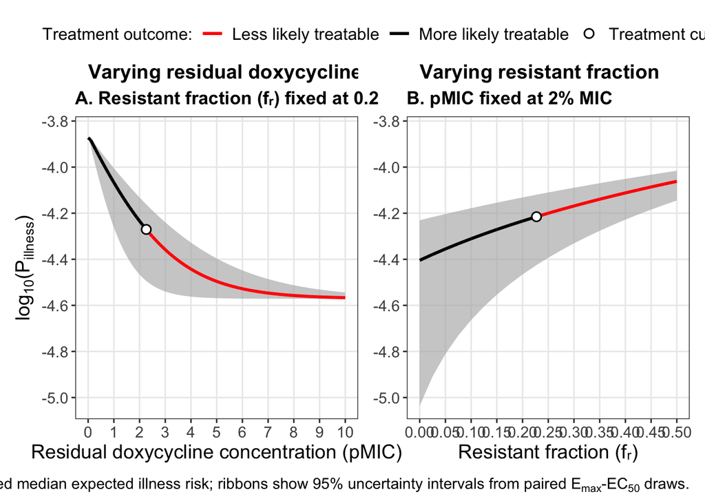

```r
add_cutoff_row <- function(data, vary_by, cutoff,
                           fixed_fr = NULL, fixed_pMIC = NULL) {
  if (!is.finite(cutoff)) return(data)

  bind_rows(
    data,
    summarise_risk(vary_by, cutoff, fixed_fr, fixed_pMIC)
  ) |>
    distinct(value, .keep_all = TRUE) |>
    arrange(value)
}

risk_limits_log10 <- function(...) {
  x <- bind_rows(...)
  limits <- range(
    c(x$lower95_expected_risk, x$upper95_expected_risk),
    na.rm = TRUE
  )

  stopifnot(limits[1] > 0)
  log10(limits)
}

# Four scenarios: two combined conditions and two reference conditions
risk_summary_pMIC <- summarise_risk("pMIC", pMIC_seq, fixed_fr = fr_fixed)
risk_summary_fr <- summarise_risk("fr", fr_seq, fixed_pMIC = pMIC_fixed)
risk_summary_pMIC_fr0 <- summarise_risk("pMIC", pMIC_seq, fixed_fr = 0)
risk_summary_fr_pMIC0 <- summarise_risk("fr", fr_seq, fixed_pMIC = 0)

cutoff_pMIC <- find_cutoff(
  risk_summary_pMIC, "pMIC",
  fixed_fr = fr_fixed,
  tolerance = 0.001
)

cutoff_fr <- find_cutoff(
  risk_summary_fr, "fr",
  fixed_pMIC = pMIC_fixed,
  tolerance = 0.0001
)

cutoff_fr_pMIC0 <- find_cutoff(
  risk_summary_fr_pMIC0, "fr",
  fixed_pMIC = 0,
  tolerance = 0.0001
)

risk_summary_pMIC_plot <- add_cutoff_row(
  risk_summary_pMIC, "pMIC", cutoff_pMIC,
  fixed_fr = fr_fixed
)

risk_summary_fr_plot <- add_cutoff_row(
  risk_summary_fr, "fr", cutoff_fr,
  fixed_pMIC = pMIC_fixed
)

risk_summary_pMIC_fr0_plot <- risk_summary_pMIC_fr0

risk_summary_fr_pMIC0_plot <- add_cutoff_row(
  risk_summary_fr_pMIC0, "fr", cutoff_fr_pMIC0,
  fixed_pMIC = 0
)

expected_risk_limits_selected <- risk_limits_log10(
  risk_summary_pMIC_plot,
  risk_summary_fr_plot
)

expected_risk_limits_reference <- risk_limits_log10(
  risk_summary_pMIC_fr0_plot,
  risk_summary_fr_pMIC0_plot
)

plot_expected_risk <- function(data, panel_label, fixed_text,
                               x_title, x_breaks, y_limits,
                               cutoff = NA_real_, show_y = TRUE,
                               show_legend = FALSE) {
  risk_legend_levels <- c(
    "Treatment outcome:",
    "Less likely treatable",
    "More likely treatable",
    "Treatment cut-point"
  )

  stopifnot(all(
    data$lower95_expected_risk > 0,
    data$median_expected_risk > 0,
    data$upper95_expected_risk > 0
  ))

  data <- data |>
    mutate(
      outcome = factor(
        outcome,
        levels = c("Less likely treatable", "More likely treatable")
      ),
      log10_lower95 = log10(lower95_expected_risk),
      log10_median_risk = log10(median_expected_risk),
      log10_upper95 = log10(upper95_expected_risk)
    )

  segments <- data.frame(
    x = head(data$value, -1),
    xend = tail(data$value, -1),
    y = head(data$log10_median_risk, -1),
    yend = tail(data$log10_median_risk, -1),
    outcome = head(data$outcome, -1)
  )

  p <- ggplot(data, aes(value)) +
    geom_ribbon(
      aes(ymin = log10_lower95, ymax = log10_upper95),
      fill = "grey70",
      alpha = 0.65
    ) +
    geom_segment(
      data = segments,
      aes(
        x = x, xend = xend,
        y = y, yend = yend,
        colour = outcome,
        linetype = outcome
      ),
      linewidth = 1.05,
      show.legend = show_legend
    ) +
    scale_colour_manual(
      name = NULL,
      limits = risk_legend_levels,
      breaks = risk_legend_levels,
      values = c(
        "Treatment outcome:" = "transparent",
        "Less likely treatable" = "red",
        "More likely treatable" = "black",
        "Treatment cut-point" = "black"
      ),
      drop = FALSE
    ) +
    scale_linetype_manual(
      name = NULL,
      limits = risk_legend_levels,
      breaks = risk_legend_levels,
      values = c(
        "Treatment outcome:" = "blank",
        "Less likely treatable" = "solid",
        "More likely treatable" = "solid",
        "Treatment cut-point" = "blank"
      ),
      drop = FALSE
    ) +
    scale_shape_manual(
      name = NULL,
      limits = risk_legend_levels,
      breaks = risk_legend_levels,
      values = c(
        "Treatment outcome:" = NA,
        "Less likely treatable" = NA,
        "More likely treatable" = NA,
        "Treatment cut-point" = 21
      ),
      drop = FALSE
    ) +
    scale_x_continuous(breaks = x_breaks) +
    scale_y_continuous(
      limits = y_limits,
      breaks = scales::breaks_pretty(n = 6),
      expand = expansion(mult = c(0.05, 0.08))
    ) +
    labs(
      title = NULL,
      subtitle = paste0(panel_label, ". ", fixed_text),
      x = x_title,
      y = if (show_y) expression(log[10] * "(" * P[illness] * ")") else NULL
    ) +
    guides(
      colour = guide_legend(order = 1, nrow = 1),
      linetype = guide_legend(order = 1, nrow = 1),
      shape = guide_legend(order = 1, nrow = 1)
    ) +
    theme_bw(base_size = 11) +
    theme(
      plot.title = element_blank(),
      plot.subtitle = element_text(
        face = "bold", size = 13,
        margin = margin(b = 6)
      ),
      axis.title.x = element_text(size = 14),
      axis.title.y = element_text(size = 14),
      axis.text = element_text(size = 11),
      legend.title = element_text(size = 12),
      legend.text = element_text(size = 12),
      panel.grid.minor = element_blank(),
      legend.position = if (show_legend) "top" else "none",
      legend.box = "horizontal",
      legend.box.just = "center"
    )

  if (is.finite(cutoff)) {
    cutoff_data <- data[which.min(abs(data$value - cutoff)), ]

    p <- p +
      geom_point(
        data = cutoff_data,
        aes(
          x = value,
          y = log10_median_risk,
          shape = "Treatment cut-point"
        ),
        inherit.aes = FALSE,
        size = 2.6,
        stroke = 0.8,
        colour = "black",
        fill = "white",
        show.legend = show_legend
      )
  }

  p
}

make_column_title <- function(label) {
  ggplot() +
    annotate(
      "text", x = 0, y = 0.5,
      label = label,
      hjust = 0,
      fontface = "bold",
      size = 5
    ) +
    xlim(0, 1) +
    ylim(0, 1) +
    theme_void()
}

column_title_pMIC <- make_column_title(
  "Varying residual doxycycline concentration"
)
column_title_fr <- make_column_title("Varying resistant fraction")

assemble_expected_risk <- function(left_plot, right_plot) {
  patchwork::wrap_plots(
    A = left_plot,
    B = right_plot,
    C = column_title_pMIC,
    D = column_title_fr,
    E = patchwork::guide_area(),
    design = "
  EE
  CD
  AB
  ",
    heights = c(0.12, 0.08, 1),
    guides = "collect"
  ) +
    patchwork::plot_annotation(
      title = NULL,
     caption = expression(
  "Lines show log"[10] * "-transformed median expected illness risk; ribbons show 95% uncertainty intervals from paired " *
    E[max] * "-" * EC[50] * " draws."
),
      theme = theme(
        plot.caption = element_text(size = 11, hjust = 1)
      )
    )
}

# Combined-condition figure retained in the main manuscript
plot_A <- plot_expected_risk(
  risk_summary_pMIC_plot,
  panel_label = "A",
  fixed_text = paste0("Resistant fraction (fᵣ) fixed at ", fr_fixed),
  x_title = "Residual doxycycline concentration (pMIC)",
  x_breaks = pMIC_breaks,
  y_limits = expected_risk_limits_selected,
  cutoff = cutoff_pMIC,
  show_legend = TRUE
)

plot_B <- plot_expected_risk(
  risk_summary_fr_plot,
  panel_label = "B",
  fixed_text = paste0("pMIC fixed at ", pMIC_fixed, "% MIC"),
  x_title = "Resistant fraction (f\u1D63)",
  x_breaks = fr_breaks,
  y_limits = expected_risk_limits_selected,
  cutoff = cutoff_fr,
  show_y = FALSE
)

expected_risk_selected_panels <- assemble_expected_risk(plot_A, plot_B)

save_plot(
  expected_risk_selected_panels,
  "expected_risk_selected_panels.png",
  width = 12,
  height = 5.5
)
```

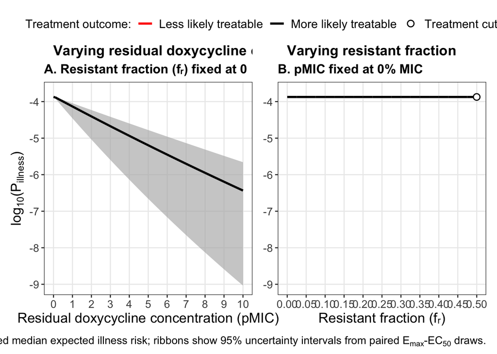

```r
# Reference-condition figure saved separately
plot_reference_A <- plot_expected_risk(
  risk_summary_pMIC_fr0_plot,
  panel_label = "A",
  fixed_text = "Resistant fraction (fᵣ) fixed at 0",
  x_title = "Residual doxycycline concentration (pMIC)",
  x_breaks = pMIC_breaks,
  y_limits = expected_risk_limits_reference,
  show_legend = FALSE
)

plot_reference_B <- plot_expected_risk(
  risk_summary_fr_pMIC0_plot,
  panel_label = "B",
  fixed_text = "pMIC fixed at 0% MIC",
  x_title = "Resistant fraction (f\u1D63)",
  x_breaks = fr_breaks,
  y_limits = expected_risk_limits_reference,
  cutoff = cutoff_fr_pMIC0,
  show_y = FALSE,
  show_legend = TRUE
)

expected_risk_reference_panels <- assemble_expected_risk(plot_reference_A, plot_reference_B)

save_plot(
  expected_risk_reference_panels,
  "expected_risk_reference_panels.png",
  width = 12,
  height = 5.5
)
```

```r
# One CSV containing the four scenarios at labelled x-axis values
format_expected_risk_export <- function(data, figure, panel,
                                        fixed_condition, x_parameter,
                                        selected_x_values) {
  data |>
    filter(
      round(value, 6) %in%
        round(selected_x_values, 6)
    ) |>
    transmute(
      Figure = figure,
      Panel = panel,
      Fixed_condition = fixed_condition,
      X_axis_parameter = x_parameter,
      X_axis_value = value,
      Treatment_outcome = outcome,
      Mean_log10_expected_illness_risk = Mean_log10_expected_risk,
      P2.5_log10_expected_illness_risk = P2.5_log10_expected_risk,
      P25_log10_expected_illness_risk = P25_log10_expected_risk,
      Median_log10_expected_illness_risk = Median_log10_expected_risk,
      P75_log10_expected_illness_risk = P75_log10_expected_risk,
      P97.5_log10_expected_illness_risk = P97.5_log10_expected_risk,
      Minimum_log10_expected_illness_risk = Minimum_log10_expected_risk,
      Maximum_log10_expected_illness_risk = Maximum_log10_expected_risk
    )
}

expected_risk_four_scenarios_csv <- bind_rows(
  format_expected_risk_export(
    risk_summary_pMIC_fr0,
    "Reference conditions", "A",
    "Resistant fraction = 0",
    "pMIC (% MIC)",
    pMIC_breaks
  ),
  format_expected_risk_export(
    risk_summary_fr_pMIC0,
    "Reference conditions", "B",
    "pMIC = 0% MIC",
    "Resistant fraction",
    fr_breaks
  ),
  format_expected_risk_export(
    risk_summary_pMIC,
    "Combined conditions", "A",
    paste0("Resistant fraction = ", fr_fixed),
    "pMIC (% MIC)",
    pMIC_breaks
  ),
  format_expected_risk_export(
    risk_summary_fr,
    "Combined conditions", "B",
    paste0("pMIC = ", pMIC_fixed, "% MIC"),
    "Resistant fraction",
    fr_breaks
  )
)

print(expected_risk_four_scenarios_csv)
```

```
##                  Figure Panel          Fixed_condition   X_axis_parameter
## 1  Reference conditions     A   Resistant fraction = 0       pMIC (% MIC)
## 2  Reference conditions     A   Resistant fraction = 0       pMIC (% MIC)
## 3  Reference conditions     A   Resistant fraction = 0       pMIC (% MIC)
## 4  Reference conditions     A   Resistant fraction = 0       pMIC (% MIC)
## 5  Reference conditions     A   Resistant fraction = 0       pMIC (% MIC)
## 6  Reference conditions     A   Resistant fraction = 0       pMIC (% MIC)
## 7  Reference conditions     A   Resistant fraction = 0       pMIC (% MIC)
## 8  Reference conditions     A   Resistant fraction = 0       pMIC (% MIC)
## 9  Reference conditions     A   Resistant fraction = 0       pMIC (% MIC)
## 10 Reference conditions     A   Resistant fraction = 0       pMIC (% MIC)
## 11 Reference conditions     A   Resistant fraction = 0       pMIC (% MIC)
## 12 Reference conditions     B            pMIC = 0% MIC Resistant fraction
## 13 Reference conditions     B            pMIC = 0% MIC Resistant fraction
## 14 Reference conditions     B            pMIC = 0% MIC Resistant fraction
```

[output cut: 255 more lines]

```r
dir.create("results", showWarnings = FALSE)

write.csv(
  expected_risk_four_scenarios_csv,
  file.path(
    "results",
    "expected_illness_risk_four_scenarios_log10.csv"
  ),
  row.names = FALSE
)
```

# 7 Illness-risk CDF

Within each uncertainty draw, the empirical CDF describes variability among shrimp-consumption days. The median and pointwise 95% interval of these CDFs across the outer draws show uncertainty around the variability distribution.

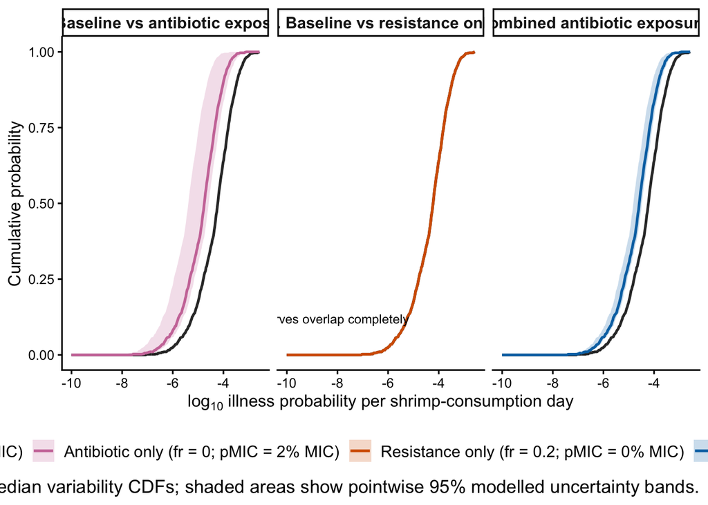

```r
cdf_scenarios <- data.frame(
  scenario_id = c(
    "Baseline",
    "Antibiotic only",
    "Resistance only",
    "Combined"
  ),
  scenario = c(
    "Baseline (fr = 0; pMIC = 0% MIC)",
    paste0("Antibiotic only (fr = 0; pMIC = ",
           pMIC_fixed, "% MIC)"),
    paste0("Resistance only (fr = ", fr_fixed,
           "; pMIC = 0% MIC)"),
    paste0("Antibiotic and resistance (fr = ", fr_fixed,
           "; pMIC = ", pMIC_fixed, "% MIC)")
  ),
  fr = c(0, 0, fr_fixed, fr_fixed),
  pMIC = c(0, pMIC_fixed, 0, pMIC_fixed)
)

cdf_results <- pmap(cdf_scenarios[c("fr", "pMIC")], run_scenario)
log_risk <- map(cdf_results, ~log10(pmax(.x$risk, .Machine$double.xmin)))

log_risk_grid <- seq(
  min(unlist(log_risk)),
  max(unlist(log_risk)),
  length.out = 300
)

cdf_data <- map2_dfr(log_risk, seq_along(log_risk), function(x, k) {
  cdf_matrix <- vapply(
    seq_len(n_outer),
    function(j) ecdf(x[, j])(log_risk_grid),
    numeric(length(log_risk_grid))
  )

  q <- t(apply(
    cdf_matrix, 1, quantile,
    probs = c(0.025, 0.50, 0.975), names = FALSE
  ))

  data.frame(
    log10_risk = log_risk_grid,
    lower95 = q[, 1],
    median = q[, 2],
    upper95 = q[, 3],
    scenario_id = cdf_scenarios$scenario_id[k],
    scenario = cdf_scenarios$scenario[k]
  )
}) |>
  mutate(scenario = factor(scenario, levels = cdf_scenarios$scenario))

cdf_colours <- setNames(
  c("#333333", "#CC79A7", "#D55E00", "#0072B2"),
  cdf_scenarios$scenario
)

comparison_sets <- list(
  "A. Baseline vs antibiotic exposure" = c("Baseline", "Antibiotic only"),
  "B. Baseline vs resistance only" = c("Baseline", "Resistance only"),
  "C. Baseline vs combined antibiotic exposure and resistance" =
    c("Baseline", "Combined")
)

comparison_cdf_data <- imap_dfr(comparison_sets, function(scenarios, name) {
  filter(cdf_data, scenario_id %in% scenarios) |>
    mutate(comparison = name)
}) |>
  mutate(comparison = factor(comparison, levels = names(comparison_sets)))

overlap_note <- data.frame(
  comparison = factor(
    "B. Baseline vs resistance only",
    levels = names(comparison_sets)
  ),
  x = quantile(log_risk_grid, 0.25),
  y = 0.12,
  label = "Curves overlap completely"
)

illness_risk_cdf_comparisons <- ggplot(
  comparison_cdf_data,
  aes(x = log10_risk, colour = scenario, fill = scenario)
) +
  geom_ribbon(
    aes(ymin = lower95, ymax = upper95),
    alpha = 0.22,
    colour = NA
  ) +
  geom_line(aes(y = median), linewidth = 0.9) +
  geom_text(
    data = overlap_note,
    aes(x = x, y = y, label = label),
    inherit.aes = FALSE,
    size = 3.2
  ) +
  facet_wrap(~comparison, nrow = 1) +
  scale_colour_manual(name = "Scenario", values = cdf_colours) +
  scale_fill_manual(name = "Scenario", values = cdf_colours) +
  scale_y_continuous(
    limits = c(0, 1),
    breaks = seq(0, 1, by = 0.25)
  ) +
  labs(
  title = NULL,
  x = expression(log[10] * " illness probability per shrimp-consumption day"),
  y = "Cumulative probability",
  caption = paste(
    "Lines show median variability CDFs; shaded areas show",
    "pointwise 95% modelled uncertainty bands."
  )
) +
theme_classic(base_size = 12) +
theme(
  plot.title = element_blank(),
  strip.text = element_text(face = "bold", size = 11.5),
  legend.title = element_text(size = 13),
  legend.text = element_text(size = 11.5),
  plot.caption = element_text(size = 13, hjust = 1),
  legend.position = "bottom",
  legend.box = "horizontal"
)

save_plot(
  illness_risk_cdf_comparisons,
  "illness_risk_cdf_scenario_comparisons.png",
  width = 15,
  height = 6
)
```

# 8 Delta P_treat across the dose range

This analysis uses the fixed dose grid from the conditional dose-response analysis. At each dose, Delta P_treat is calculated for the paired Emax-EC50 uncertainty draws. Exposure variability is not included in these figures. Positive values indicate that a more-treatable outcome is more likely; values at or below zero indicate that a less-treatable outcome is more likely.

```r
make_delta_curve <- function(fr, pMIC, group, panel) {
  q <- apply(run_dose_grid(fr, pMIC)$delta, 2, quantile, probs = c(0.025, 0.50, 0.975), names = FALSE)

  data.frame(
    dose = dose_grid,
    lower95 = q[1, ],
    median_delta = q[2, ],
    upper95 = q[3, ],
    group = group,
    panel = panel
  )
}

plot_delta_curve <- function(data, title, legend_title, colours, file_name) {
  data <- mutate(data, log10_dose = log10(dose))

  dose_reference_lines <- data.frame(
    log10_dose = log10(dose_percentiles),
    reference = factor(
      c("95% dose variability", "Median dose", "95% dose variability"),
      levels = c("Median dose", "95% dose variability")
    )
  )

  dose_reference_linetypes <- c(
    "Median dose" = "solid",
    "95% dose variability" = "dashed"
  )

  p <- ggplot(
    data,
    aes(log10_dose, median_delta, colour = group, fill = group)
  ) +
    geom_ribbon(
      aes(ymin = lower95, ymax = upper95),
      alpha = 0.40, colour = NA, show.legend = FALSE
    ) +
    geom_vline(
      data = dose_reference_lines,
      aes(xintercept = log10_dose, linetype = reference),
      inherit.aes = FALSE, colour = "grey30", linewidth = 0.40
    ) +
    geom_line(linewidth = 1.05) +
    geom_hline(
      yintercept = 0, colour = "black",
      linetype = "dotted", linewidth = 0.35
    ) +
    facet_wrap(~panel, nrow = 1) +
    scale_x_continuous(breaks = scales::breaks_pretty(n = 6)) +
    scale_y_continuous(labels = scales::label_scientific()) +
    scale_colour_manual(
      name = legend_title,
      values = colours,
      breaks = names(colours)
    ) +
    scale_fill_manual(values = colours, breaks = names(colours)) +
    scale_linetype_manual(
      name = "Exposure dose",
      values = dose_reference_linetypes
    ) +
    labs(
      title = title,
      x = expression(
        log[10] * "(pathogenic dose [MPN per shrimp-consumption day])"
      ),
      y = expression(Delta * P[treat]),
      caption = expression(
        "Curves show medians; ribbons show pointwise 95% uncertainty " *
          "intervals from paired " * E[max] * "-" * EC[50] * " simulations."
      )
    ) +
    guides(
      fill = "none",
      colour = guide_legend(order = 1, nrow = 1),
      linetype = guide_legend(order = 2, nrow = 1)
    ) +
    theme_bw(base_size = 14) +
theme(
  plot.title = element_text(face = "bold", size = 18),
  axis.title = element_text(size = 16),
  axis.text = element_text(size = 13),
  strip.text = element_text(face = "bold", size = 15),
  legend.title = element_text(size = 14),
  legend.text = element_text(size = 13),
  plot.caption = element_text(size = 12),
  panel.grid.minor = element_blank(),
  legend.position = "top",
  legend.box = "vertical",
  legend.spacing.y = grid::unit(0.15, "cm"),
  legend.key.width = grid::unit(1.1, "cm")
)

  save_plot(p, file_name, width = 12, height = 6.5)
}
```

## 8.1 Delta P_treat by residual doxycycline concentration

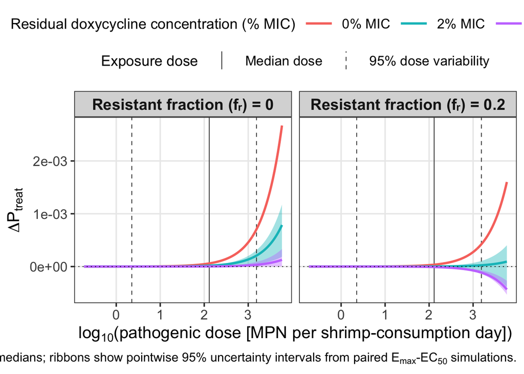

```r
delta_curve_pMIC <- expand_grid(fr = c(0, fr_fixed), pMIC = pMIC_plot) |>
  mutate(
    group = paste0(pMIC, "% MIC"),
    panel = paste0("Resistant fraction (f\u1D63) = ", fr)
  ) |>
  pmap_dfr(make_delta_curve)

plot_delta_curve(
  delta_curve_pMIC,
  title = NULL,
  legend_title = "Residual doxycycline concentration (% MIC)",
  colours = pMIC_colours,
  file_name = "delta_p_treat_across_dose_by_pMIC.png"
)
```

## 8.2 Delta P_treat by resistant fraction

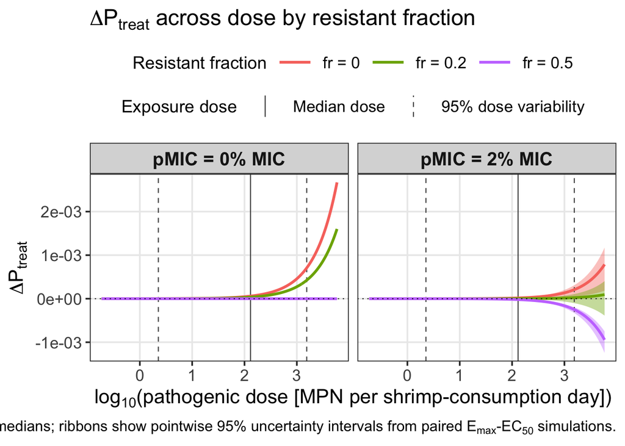

```r
delta_curve_fr <- expand_grid(pMIC = c(0, pMIC_fixed), fr = fr_plot) |>
  transmute(
    fr,
    pMIC,
    group = paste0("fr = ", fr),
    panel = paste0("pMIC = ", pMIC, "% MIC")
  ) |>
  pmap_dfr(make_delta_curve)

plot_delta_curve(
  delta_curve_fr,
  title = expression(Delta * P[treat] * " across dose by resistant fraction"),
  legend_title = "Resistant fraction",
  colours = fr_colours,
  file_name = "delta_p_treat_across_dose_by_fr.png"
)
```

# 9 Delta P_treat summary at the median exposure dose

For each scenario shown in the two conditional Delta P_treat figures, the distribution across the paired Emax-EC50 uncertainty draws is summarized at the median exposure dose. The treatment outcome is classified as more likely treatable when more than 50% of the uncertainty draws have a positive Delta P_treat value.

```r
summarise_delta_at_dose <- function(fr, pMIC) {
  out <- calc_sd_drm(
    dose = rep(median_dose, n_outer), fr = fr, C = pMIC / 100 * MIC,
    alpha = alpha, beta = beta, Emax = Emax_outer, EC50 = EC50_outer,
    tfs = tfs, ab_lookup = ab_lookup
  )

  x <- out$delta_p_treat
  q <- quantile(x, c(0.025, 0.25, 0.50, 0.75, 0.975), names = FALSE)
  outcome <- ifelse(mean(x > 0) > 0.5, "More likely treatable",
                    "Less likely treatable")

  data.frame(
    fr = fr, pMIC = pMIC, Median_log10_dose = median_log10_dose,
    Treatment_outcome_at_median_dose = outcome, Mean = mean(x),
    P2.5 = q[1], P25 = q[2], Median = q[3], P75 = q[4],
    P97.5 = q[5], Minimum = min(x), Maximum = max(x)
  )
}

delta_summary_pMIC <- expand_grid(fr = c(0, fr_fixed), pMIC = pMIC_plot) |>
  pmap_dfr(function(fr, pMIC) summarise_delta_at_dose(fr, pMIC)) |>
  mutate(Panel = paste0("Resistant fraction = ", fr), Scenario = paste0(pMIC, "% MIC")) |>
  select(Panel, Scenario, everything())

delta_summary_fr <- expand_grid(pMIC = c(0, pMIC_fixed), fr = fr_plot) |>
  pmap_dfr(function(pMIC, fr) summarise_delta_at_dose(fr, pMIC)) |>
  mutate(Panel = paste0("pMIC = ", pMIC, "% MIC"), Scenario = paste0("fr = ", fr)) |>
  select(Panel, Scenario, everything())

delta_summary_table <- bind_rows(
  "Varying residual doxycycline concentration" = delta_summary_pMIC,
  "Varying resistant fraction" = delta_summary_fr,
  .id = "Figure"
)

print(delta_summary_table)
```

```
##                                        Figure                    Panel Scenario
## 1  Varying residual doxycycline concentration   Resistant fraction = 0   0% MIC
## 2  Varying residual doxycycline concentration   Resistant fraction = 0   2% MIC
## 3  Varying residual doxycycline concentration   Resistant fraction = 0   5% MIC
## 4  Varying residual doxycycline concentration Resistant fraction = 0.2   0% MIC
## 5  Varying residual doxycycline concentration Resistant fraction = 0.2   2% MIC
## 6  Varying residual doxycycline concentration Resistant fraction = 0.2   5% MIC
## 7                  Varying resistant fraction            pMIC = 0% MIC   fr = 0
## 8                  Varying resistant fraction            pMIC = 0% MIC fr = 0.2
## 9                  Varying resistant fraction            pMIC = 0% MIC fr = 0.5
## 10                 Varying resistant fraction            pMIC = 2% MIC   fr = 0
## 11                 Varying resistant fraction            pMIC = 2% MIC fr = 0.2
## 12                 Varying resistant fraction            pMIC = 2% MIC fr = 0.5
##     fr pMIC Median_log10_dose Treatment_outcome_at_median_dose          Mean
## 1  0.0    0          2.114687            More likely treatable  5.963929e-05
```

[output cut: 37 more lines]

```r
dir.create("results", showWarnings = FALSE)
write.csv(delta_summary_table, file.path("results", "delta_p_treat_at_median_dose_summary.csv"), row.names = FALSE)
```